# STutika_ST558_Project3

Sridhar Tutika

12/13/2019

# Introduction

Purpose of this project is to develop a statistical model to predict a continuous variable using Linear Regression and Ensemble Learning Methods. Here we are predicting to predict the NBA player Salary continuous variable based on his game stats such as efficiency (PER), average points, assists and blocks using supervised learning method Multiple Linear regression.

# Player Stats data

Source of the Data is NBA Player and Game data downloaded from [Kaggle](https://www.kaggle.com/schmadam97/nba-regular-season-stats-20182019#)

The source file contains around NBA stats from all games in all seasons from 2000-01 to 2018-19 season

## Preview of the Data of top 10 NBA players from 2018-19 season

GGally package a quick summary of key variables and their relation wrt to NBA Player stats.

A plot of team, points vs salary for 10 players regions shows how the salary is varied

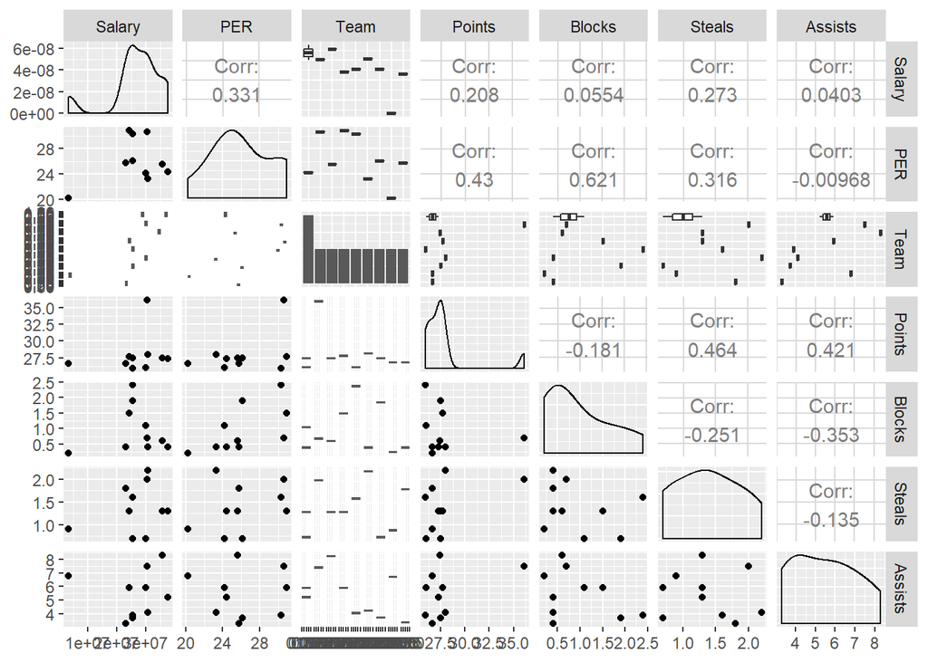

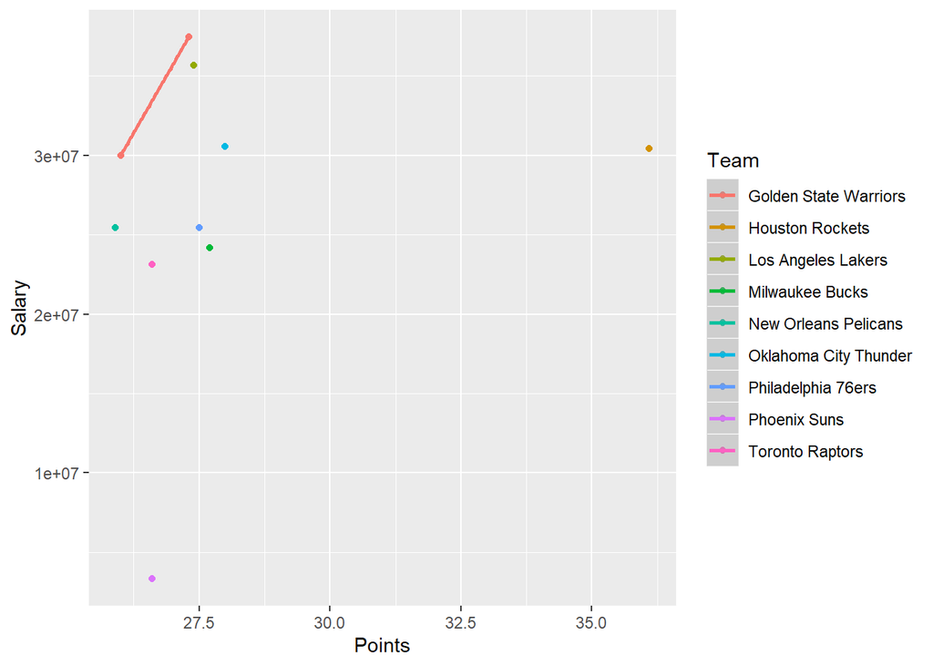

Above plots indicate the categorical variables such as Team name, type has good amount of correlation wrt to Salary.

# Data split

NBA Player data then has been split into 80% train set used to develop the model and then 20% to test set to evaluate the developed model

Randomly selecting the rows from 80% of the data by sample function The Idea is to develop a model on train set (data frame train) and test the model(data frame test) on the test set with the data that is not used to develop the model.

Preview of test and train

```
## # A tibble: 6 x 27
##   Name  Height Weight Team    Age Salary Points Blocks Steals Assists
##   <chr>  <dbl>  <dbl> <chr> <dbl>  <dbl>  <dbl>  <dbl>  <dbl>   <dbl>
## 1 Kevi~     81    215 New ~    19 3.74e6   12.8    0.3    0.6     1.1
## 2 D'An~     77    198 Broo~    22 7.02e6   21.1    0.2    1.2     7
## 3 Devi~     78    210 Phoe~    22 3.31e6   26.6    0.2    0.9     6.8
## 4 Shel~     75    203 Orla~    28 1.00e6    7.5    0.1    0.8     3.2
## 5 Darr~     72    175 Indi~    31 1.00e7   11.2    0.1    1.4     6
## 6 Taur~     80    220 Atla~    24 2.53e6   13.5    0.3    1       2.1
## # ... with 17 more variables: Rebounds <dbl>, `FT%` <dbl>, FTA <dbl>,
## #   `FG3%` <dbl>, FG3A <dbl>, `FG%` <dbl>, FGA <dbl>, MP <dbl>, G <dbl>,
## #   PER <dbl>, OWS <dbl>, DWS <dbl>, WS <dbl>, WS48 <dbl>, USG <dbl>,
## #   BPM <dbl>, VORP <dbl>
```

```
## # A tibble: 6 x 27
##   Name  Height Weight Team    Age Salary Points Blocks Steals Assists
##   <chr>  <dbl>  <dbl> <chr> <dbl>  <dbl>  <dbl>  <dbl>  <dbl>   <dbl>
## 1 Kevi~     81    240 Gold~    30 3.00e7   26      1.1    0.7     5.9
## 2 Brad~     77    207 Wash~    25 2.54e7   25.6    0.7    1.5     5.5
## 3 Kemb~     73    184 Char~    28 1.20e7   25.6    0.4    1.2     5.9
## 4 Niko~     84    260 Orla~    28 1.27e7   20.8    1.1    1       3.8
## 5 Niko~     84    250 Denv~    23 2.46e7   20.1    0.7    1.4     7.3
## 6 Kevi~     82    251 Clev~    30 2.41e7   17      0.2    0.3     2.2
## # ... with 17 more variables: Rebounds <dbl>, `FT%` <dbl>, FTA <dbl>,
## #   `FG3%` <dbl>, FG3A <dbl>, `FG%` <dbl>, FGA <dbl>, MP <dbl>, G <dbl>,
## #   PER <dbl>, OWS <dbl>, DWS <dbl>, WS <dbl>, WS48 <dbl>, USG <dbl>,
## #   BPM <dbl>, VORP <dbl>
```

# Data preprocessing

Data preprocessing involves transforming data into a basic form that makes it easy to work with. Machine learning algorithms require the data to be in a specific form. Whereas other algorithms can perform better if the data is prepared in a specific way, but not always. Finally, your raw data may not be in the best format to best expose the underlying structure and relationships to the predicted variables.

It is important to prepare the data in such a way that it gives various different machine learning algorithms the best chance on your problem.

We need to pre-process the raw data as part of machine learning project. The data has been centered and scaled when doing the Ensemble learning model below with caret package, with the option of preProcess = c(“center”, “scale”).

The scale transform calculates the standard deviation for an attribute and divides each value by that standard deviation.

The center transform calculates the mean for an attribute and subtracts it from each value.

The categorical variables have been converted into numerical classes for prediction accuracy.

Computational nuances are handles using trainControl function in caret package using method = “repeatedcv”, number = 10, repeats = 3 parameters.

# Linear Regression

A Multiple Linear regression models has been developed and evaluated such as efficiency (PER), average points, assists and blocks using supervised learning method. Here we will use AIC, AICC and BIC and Adj R Square for evaluating the accuracy of the Linear Model.

```
##
## Call:
## lm(formula = Salary ~ Points + PER + Age + Blocks + Steals +
##     Assists + Rebounds, data = df_plr_train)
##
## Coefficients:
## (Intercept)       Points          PER          Age       Blocks
##   -18034935       515889       -74450       622709       334111
##      Steals      Assists     Rebounds
##     2787390       366088       604095
```

```
##        fitStat   mlr_fit
## 1 Adj R Square     0.528
## 2          AIC 11783.654
## 3         AICc 11784.188
## 4          BIC 11818.297
```

# Ensemble model fit - Boosting

Here we developed a predictive model for Salary continuous variable using Boosting ensemble learning method. This model is similar to Bagging but we slowly grow the trees so we don’t over fit the model. We will develop the model using Caret package and also gbm library to better view the plots.

## Boosting using Caret Package

```
## Stochastic Gradient Boosting
##
## 347 samples
##   7 predictor
##
## Pre-processing: centered (7), scaled (7)
## Resampling: Cross-Validated (10 fold, repeated 3 times)
## Summary of sample sizes: 312, 312, 311, 313, 314, 313, ...
## Resampling results across tuning parameters:
##
##   interaction.depth  n.trees  RMSE     Rsquared   MAE
##   1                   50      5758671  0.5032831  4291761
##   1                  100      5779700  0.4997848  4400994
##   1                  150      5829741  0.4932356  4448035
##   2                   50      5408521  0.5623607  3890275
##   2                  100      5491554  0.5508806  3943797
##   2                  150      5603521  0.5359017  4034536
##   3                   50      5496662  0.5464358  3968528
##   3                  100      5605136  0.5337321  4034347
##   3                  150      5714810  0.5198080  4112520
##
## Tuning parameter 'shrinkage' was held constant at a value of 0.1
##
## Tuning parameter 'n.minobsinnode' was held constant at a value of 10
## RMSE was used to select the optimal model using the smallest value.
## The final values used for the model were n.trees = 50, interaction.depth
##  = 2, shrinkage = 0.1 and n.minobsinnode = 10.
```

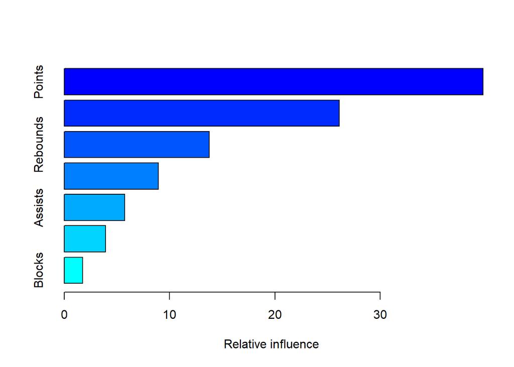

```
##               var   rel.inf
## Points     Points 39.745893
## Age           Age 26.120235
## Rebounds Rebounds 13.776468
## Steals     Steals  8.950321
## Assists   Assists  5.745278
## PER           PER  3.911118
## Blocks     Blocks  1.750688
```

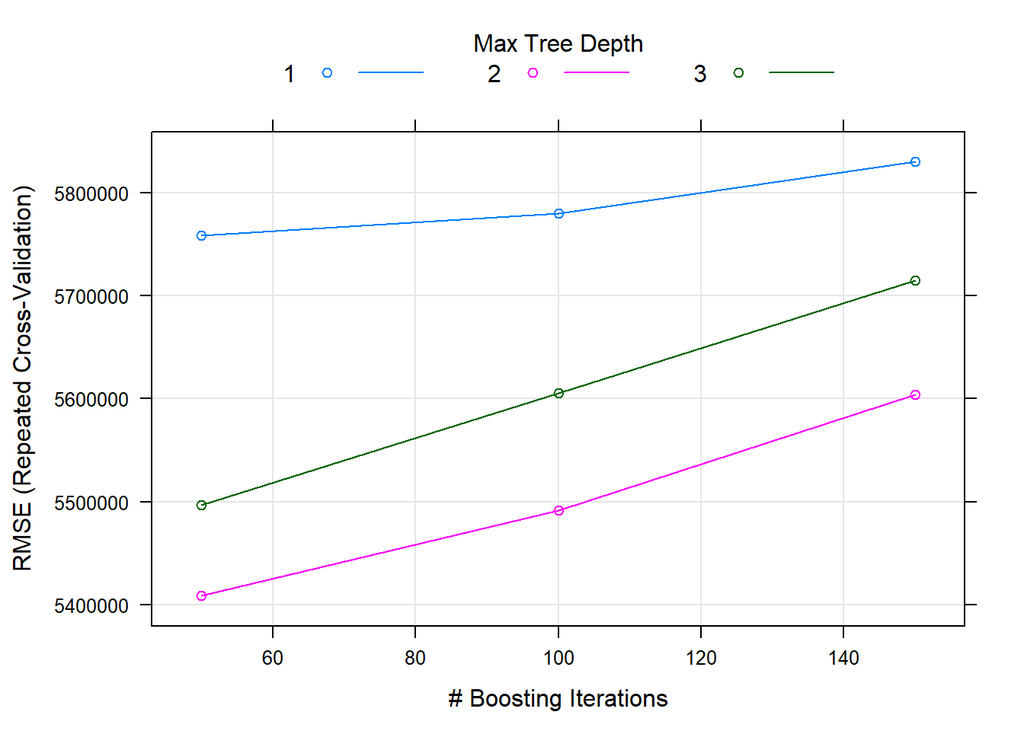

The summary indicates the relative importance of variables in determining the Salary.

# Test set Prediction

The Developed models have been tested on test set to predict the Salary. The values are compared for the first 6 observations for a summary view.

```
## # A tibble: 6 x 5
##   Name           Team                    Salary mlr_fit_pred Salary_Boosted
##   <chr>          <chr>                    <dbl>        <dbl>          <dbl>
## 1 Kevin Durant   Golden State Warriors 30000000    20602572.      27160033.
## 2 Bradley Beal   Washington Wizards    25434263    18639902.      20385873.
## 3 Kemba Walker   Charlotte Hornets     12000000    19288551.      21512454.
## 4 Nikola Vucevic Orlando Magic         12750000    20028114.      24425672.
## 5 Nikola Jokic   Denver Nuggets        24605181    18031589.      15571256.
## 6 Kevin Love     Cleveland Cavaliers   24119025    16257740.      18747024.
```

# Conclusions

A well-fitting regression model results in predicted values close to the observed data values. Three statistics are used in Ordinary Least Squares (OLS) regression to evaluate model fit: R-squared, the overall F-test, and the Root Mean Square Error (RMSE). There are situations in which a high R-squared is not necessary or relevant. When the interest is in the relationship between variables, not in prediction, the R-square is less important.

The RMSE is the square root of the variance of the residuals. It indicates the absolute fit of the model to the data–how close the observed data points are to the model’s predicted values. Whereas R-squared is a relative measure of fit, RMSE is an absolute measure of fit.

## RMSE Comparison

RMSE is the standard deviation of the residuals (prediction errors). Residuals are a measure of how far from the regression line data points are; RMSE is a measure of how spread out these residuals are. In other words, it tells you how concentrated the data is around the line of best fit.

Root Mean Squared Error Comparison

| mlr_fit_test | mlr_fit_train | gbm1_fit_test | gbm1_fit_train |
| --- | --- | --- | --- |
| 4683989 | 5578624 | 5246146 | 4588654 |

## Scatter Plot of Predicted vs actual

As the Multiple regression was developed for Salary is compared with the actual values of the test set and a scatter plot has been developed for comparison and correlation of first 100 observations of the test data.

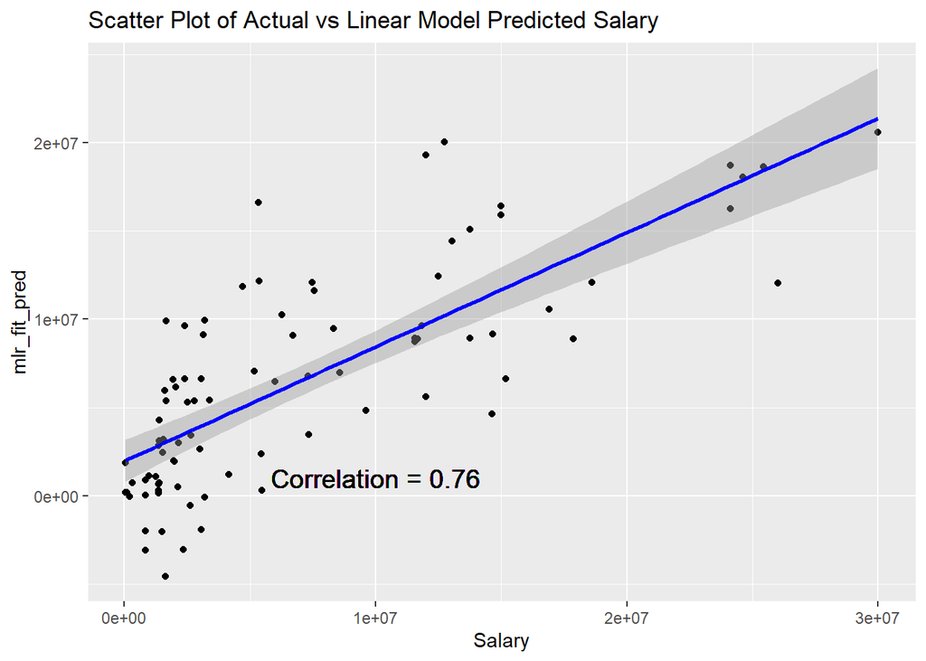

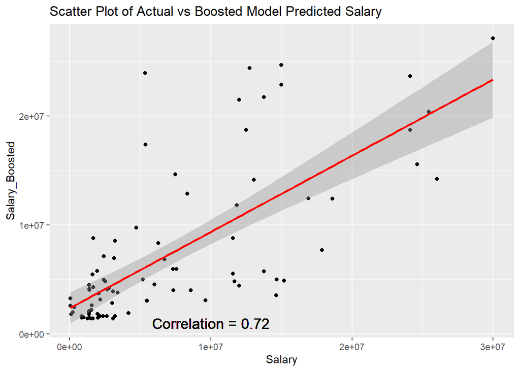

## Evaluation Summary

Based on the MSE error rate calculation, Multiple regression shows the lower error rate in test set compared with that of Boosted model. At the same time, training set error was significantly low in boosted model.

The boosted trees model correlation of predicted vs actual Salary values is slightly lesser than the Linear regression. When 100 observations of test data are measured, Boosted model has a correlation of 0.72 compared to linear model’s 0.76

Based on the analysis, we can conclude that Linear regression model performance is better and this can be used to predict a player’s salary.